# Introduction to R programming for data science Day 2 exercises

Dr. Francesca Finotello

Medical University of Innsbruck, Austria

# File paths

## Ex. 2.1

Open R and print to screen your current working directory.

```r
getwd()
```

```
## [1] "/Users/francescafinotello/Dropbox/R_course_MUI_2021/Solutions"
```

Create a directory on your Desktop called *Rcourse_day2*. You can do it manually or using the **dir.create** function.

*Tip*: use the **help** function to understand how **dir.create** is supposed to work.

```r
help(dir.create)
dir.create("/Users/francescafinotello/Desktop/Rcourse_day2", showWarnings = FALSE)
```

Create two sub-directories in the *Rcourse_day2* directory called *Data* and *Scripts*.

```r
dir.create("/Users/francescafinotello/Desktop/Rcourse_day2/Data", showWarnings = FALSE)
dir.create("/Users/francescafinotello/Desktop/Rcourse_day2/Scripts", showWarnings = FALSE)
```

Change your working directory to the *Scripts* subfolder and check whether the change has been successful.

```r
setwd("/Users/francescafinotello/Desktop/Rcourse_day2/Scripts")
getwd()
```

```
## [1] "/Users/francescafinotello/Desktop/Rcourse_day2/Scripts"
```

# R data and scripts

## Ex. 2.2

Initialize two numeric vectors, *b* equal to 5 and *h* equal to 4, with the base and height of a triangle.

```r
b <- 5
h <- 4
```

Save the *b* and *h* objects in the *Data* sub-directory, in a file named *triangle.RData*.

```r
save(b, h, file = "../Data/triangle.RData")
```

## Ex. 2.3

Open a new R script file from the toolbar: **File > New File > R Script**.

Copy the following text in the script:

```r
getArea <- function (base, height) {

  area <- #...

  return(area)

}
```

Substitute the commented dots with the code necessary to compute the triangle area to be assigned to the *area* variable and save the final script in *Scripts/Triangle_area.R*.

```r
getArea <- function (base, height) {

  area <- b * h / 2

  return(area)

}
```

## Ex. 2.4

Open a new R script file and save it with the name *Scripts/Day2_Ex4.R*.

In this script write the code to:

- Clean your workspace
- Load the *triangle.RData* data (from Ex. 2.2)
- Source the *Triangle_area.R* script (from Ex. 2.3)
- Apply the **getArea** function to compute the triangle area from *b* and *h* and save it into a new variable called *A*.

```r
rm( list = ls() )
load("../Data/triangle.RData")
source("Triangle_area.R")
A <- getArea(b, h)
A
```

# Applying functions to vectors

## Ex. 2.5

Initialize in R the following vectors:

```r
x <- c(1, 2, 200, 6, 80, 23)
y <- c(100, 50, 5, 30, 1, 20)
```

Then compute:

- The mean of *x* and *y*, separately.

```r
mean(x)
```

```
## [1] 52
```

```r
mean(y)
```

```
## [1] 34.33333
```

- The variance of *x* and *y*, separately.

```r
var(x)
```

```
## [1] 6149.2
```

```r
var(y)
```

```
## [1] 1350.667
```

- Spearman’s correlation of *x* and *y*.

```r
cor(x, y, method = "spearman")
```

```
## [1] -0.9428571
```

## Ex. 2.6

Initialize in R the following named vector:

```r
mLen <- c(31, 28, 31, 30,
  31, 30, 31, 31,
  30, 31, 30, 31)

names(mLen) <- c("Jan", "Feb", "Mar", "Apr",
  "May", "Jun", "Jul", "Aug",
  "Sep", "Oct", "Nov", "Dec")
```

Use the **table** function to count how many months are 31-day long.

```r
table(mLen)
```

```
## mLen
## 28 30 31
##  1  4  7
```

## Ex. 2.7

```r
y <- sort( sample( seq(1, 10), 10) )
```

## Ex. 2.8

Initialize in R the following vectors:

```r
x <- seq(1, 5)
y <- seq(3, 7)
```

Use the **intersect** and **setdiff** functions to identify the elements belonging to the colored areas in the figure below, and save them into two variables called *a* and *b*.

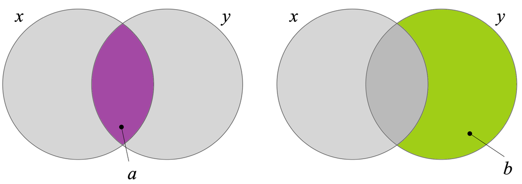

```r
a <- intersect(x, y)
a
```

```
## [1] 3 4 5
```

```r
b <- setdiff(y, x)
b
```

```
## [1] 6 7
```

## Ex. 2.9

Initialize in R the following vectors:

```r
x <- c(2, 4, 5, 7, 8)
y <- c(2, 4, 6, 8, 10)
z <- c(2, 3, 4, 5, 6)
```

Identify the elements belonging to the colored areas in the figure below, and save them into two variables *a* and *b*.

*Tip*: The **intersect** and **setdiff** functions only accept two sets, but can be combined recursively (e.g., intersection of the intersection).

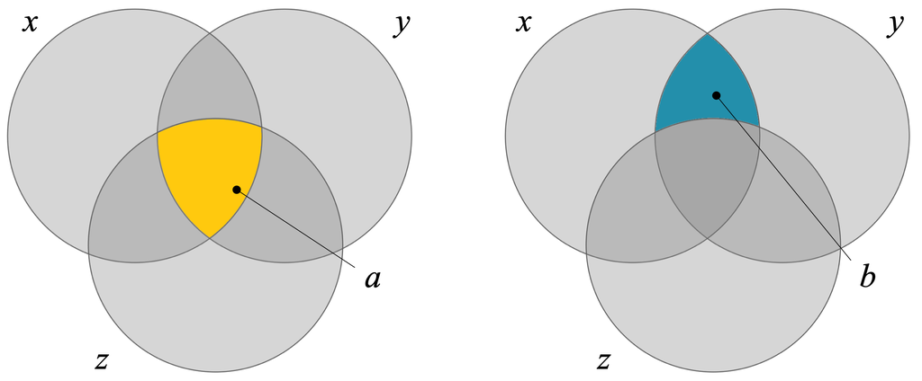

```r
a <- intersect( intersect(x, y), z )
a
```

```
## [1] 2 4
```

```r
b <- setdiff( intersect(x, y), z )
b
```

```
## [1] 8
```

## Ex. 2.10

Create a function called **firstNsum** that for a positive integer *n* specified as argument, computes the sum of the first *n* positive numbers

```r
firstNsum <- function (n) {

  Nsum <- sum(seq(1, n))
  return(Nsum)

}
```

*Tip*: use *seq* and *sum*.

Create a function called **firstNsum2** that for a positive integer *n* specified as argument, computes the following formula:

$$\frac{n(n+1)}{2}$$

```r
firstNsum2 <- function (n) {

  Nsum2 <- n * ( n + 1 ) / 2
  return(Nsum2)

}
```

Verify that the results from these two functions are the same using n=10, 20, and 100 as examples.

```r
firstNsum(10) == firstNsum2(10)
```

```
## [1] TRUE
```

```r
firstNsum(20) == firstNsum2(20)
```

```
## [1] TRUE
```

```r
firstNsum(100) == firstNsum2(100)
```

```
## [1] TRUE
```

## Ex. 2.11

Create a function called **FtoCtemp** that takes as input the temperature in Fahrenheit and converts it into Celsius using the following formula:

$$C=\frac{5}{9}(F-32)$$

```r
FtoCtemp <- function (F) {

  C = 5 * ( F -  32 ) / 9
  return(C)

}
```

Use this function to determine whether your are going to sleep comfortably in your hotel room in New York City, where the temperature is set to 47ºF.

```r
FtoCtemp(47)
```

```
## [1] 8.333333
```